# Introduction to R (offsite)

Antoine, Hilke, Karma

12 November 2018

# Goals of this workshop

- JIT learning (Just enough information to do something). There will be a lot of unanswered questions, but you should have the tools to find out how to answer them.
- Knowledge of how to setup the development environment
- How to share your work with others through markdown and HTML documents
- Practice in Dplyr and ggplot: Enough to create summaries and graphs
- Creation of shiny applications to make your analysis dynamic

*Tip: When in doubt, always experiment

# What is R?

R is a *programming language designed for statistical computing*. Notable characteristics include:

- Vast capabilities, wide range of statistical and graphical techniques
- Very popular in academia, growing popularity in business: http://r4stats.com/articles/popularity/
- Written primarily by statisticians
- FREE (no monetary cost and open source)
- Excellent community support: mailing list, blogs, tutorials
- Easy to extend by writing new functions

Whatever you’re trying to do, you’re probably not the first to try doing it R. Chances are good that someone has already written a package for that.

# Resources

Please make sure you have a copy of the following cheatsheets handy:

- Rstudio https://github.com/rstudio/cheatsheets/raw/master/rstudio-ide.pdf
- RMarkdown https://github.com/rstudio/cheatsheets/raw/master/rmarkdown-2.0.pdf
- dplyr https://github.com/rstudio/cheatsheets/raw/master/data-transformation.pdf
- ggplot https://github.com/rstudio/cheatsheets/raw/master/data-visualization-2.1.pdf
- shiny https://github.com/rstudio/cheatsheets/raw/master/shiny.pdf

Additional cheatsheets can be found here: https://www.rstudio.com/resources/cheatsheets/

# RStudio

There are 4 main windows:

- Code editor: Here you can edit R programs
- Environment window: This is like the work folder in SAS, a collection of data in memory
- Console window: Interactive code area - perfect for writing R code that you want evaluated immediately. What happens when you type `1+1` and press Enter in this window?
- Files window: Windows explorer of files and folders

# Markdown file

Markdown files are what we will use for this tutorial. Normal R files have extension .R, markdown files have the extension .Rmd. Rmd files are a record of your research, it contains the code you used and a narration to allow for reproducible research. Additionally as we will see later, you can `knit` it into various output formats (html/word/pdf…).

Code blocks are inserted via [Code][Insert chunk], the Insert button above Or alternatively by `Ctrl+Alt+i`.

### warmup 1

A simple warmup question.

You can find help on functions using the help function. For example, to find help on the `max` function, you can type `help(max)` in the console window.

1. Insert a code block
2. What is the description of the `min` funtion? Paste the result as a comment in the block you created. Comments in R are preceded by #. Place `#` before the description to comment it out.

**Insert code block below here**

The `help` function can be used to look up the documentation for a function, or to look up the documentation to a package. We can learn how to use the `dplyr` package by reading its documentation like this:

```r
help(package = "dplyr")
```

# Packages

- Imagine if could download a bunch of macros bundled together
- People all over the world could write macros and share with everyone else
- Peer review would ensure the macros work as advertised
- Packages hosted on CRAN and must pass tests to be accepted

Let’s install our first package to read SAS datasets.

install.packages specifies the name of the package we want to install. Library function loads the package into memory - Check the packages tab of RStudio to see packages that are loaded out of the installed.

```r
#install.packages("sas7bdat")
library(sas7bdat)
```

## Read in SAS dataset

We will read the ADSL dataset from the OPUS registry.

Gotcha 1: Our first gotcha: Backslashes in R have to be escaped, this means we have to add extra backslash for every backslash to our path. Alternatively, use forward slashes.

```r
adsl <- read.sas7bdat(".\\data\\adsl.sas7bdat")

#adsl <- read_sas("\\\\actelion.com\\POOL\\GLOBAL\\BIOSTATISTICS\\Clinical Projects\\ACT-064992_Macitentan\\ACT-064992_in_PAH_adult\\Regulatory Authorities\\FDC Maci and Tada\\US (FDA)\\OPUS_FDC\\ADaM_Data\\adsl.sas7bdat")
```

The “<-” is an assignment operator. Assignments can also be done with “=”, however convention dictates we use the former.

Tip: Use best practices by following the Tidyverse style guide: https://style.tidyverse.org/

We can also read a host of other formats as follows

| Data Type | Function |
| --- | --- |
| comma separated | `read_csv()` |
| tab separated | `read_delim()` |
| other delimited formats | `read_table()` |
| fixed width | `read_fwf()` |

# The dataframe object

- dataframes are the SAS equivelent of a dataset.
- Take a look at the adsl dataframe in the environment window

```r
ncol(adsl)
```

```
## [1] 132
```

```r
nrow(adsl)
```

```
## [1] 1827
```

- Names of the dataset : “names function”

```r
names(adsl)
```

```
##   [1] "STUDYID"  "USUBJID"  "SUBJID"   "SITEID"   "AGE"      "AGEU"
##   [7] "AAGE1"    "AAGEGR1"  "AAGEGR1N" "AAGE2"    "AAGEGR2"  "AAGEGR2N"
##  [13] "SEX"      "SEXN"     "BRTHDTC"  "RACE"     "ITTFL"    "FUPFL"
##  [19] "ENRLFL"   "ENRLDT"   "ARM"      "ACTARM"   "TRT01P"   "TRT01PN"
##  [25] "TRTSDT"   "TRTSDTF"  "TRTEDT"   "TRTEDTF"  "OEXPRSDT" "OEXPREDT"
##  [31] "EXPRSDT"  "EXPREDT"  "OPSMONFL" "COMBTHFL" "COHORT"   "COHORTN"
##  [37] "OPSMO7FL" "COMTH7FL" "OPSMO8FL" "COMTH8FL" "COMOTAFL" "COMOSIFL"
##  [43] "DTHDT"    "ADTHDT"   "DTHDTF"   "DTHFL"    "ADTHDTF"  "ADTHFL"
##  [49] "DTHPAHFL" "DTH30FL"  "DTHOPFL"  "DTHPOPFL" "DTHOBFL"  "DTHPOBFL"
##  [55] "DCSREAS"  "LSTINDT"  "CUTDT"    "EXPDURO"  "EXPDURE"  "PROPSDT"
##  [61] "PROPSDTF" "PROBSDT"  "PROBSDTF" "IPOPSDT"  "IPOPSDTF" "IPOBSDT"
##  [67] "IPOBSDTF" "PDEOPDT"  "PDEOPDTF" "PDEOBDT"  "PDEOBDTF" "SGCSDT"
##  [73] "SGCSDTF"  "SFRESDT"  "SFRESDTF" "SFROSDT"  "SFROSDTF" "BMIBL"
##  [79] "HEIGHTBL" "WEIGHTBL" "HRBL"     "SYSBPBL"  "DIABPBL"  "WHOFCBL"
##  [85] "SMWDBL"   "TLCPPBL"  "DLCOPPBL" "FEV1PPBL" "FVCPPBL"  "MPAPBL"
##  [91] "MRAPBL"   "MRAP1YFL" "MPCWPBL"  "PVRBL"    "BNPBL"    "NTPBNPBL"
##  [97] "RHCBLFL"  "REFBLFL"  "WHOGR1BL" "CIBL"     "RRS"      "PAHIDURM"
## [103] "PAHODURM" "PREINCO"  "PREINCON" "PREINCI"  "PREINCIN" "WHOFCFL"
## [109] "EXPSEVFL" "WHOFCID"  "WHOFCIDN" "PAHETY"   "PAHETYN"  "PRERAIFL"
## [115] "PRPDE5FL" "PRPROFL"  "PDE5DT"   "PDE5DTF"  "PDE5DUR"  "PDE5EDT"
## [121] "PDE5EDTF" "PDE5EDUR" "OXYENRFL" "DURENRFL" "CCBENRFL" "DMENRFL"
## [127] "HTENRFL"  "RIENRFL"  "AIENRFL"  "ANENRFL"  "EDENRFL"  "OHFENRFL"
```

## Introducing the pipe operator

“%>%” is the pipe operator. Similar to “|” in unix. Basically it means you don’t have to pass the name of the previous dataset between operations.

Equivalent to using “data” and “*last*” in SAS:

```sas
data;
  set sashelp.class;
  run;
data;
  set _last_;
  where age > 15;
  run;
proc print;
  var name age;
  run;
```

```r
library(dplyr)
adsl_fr <-
  adsl %>%
  filter(COHORT != "" & ITTFL == "Y")

#implicit first argument passed via pipe operator
adsl_fr <- filter(adsl, COHORT != "" & ITTFL == "Y")
```

Gotcha 2: R is case sensitive, variables are case sensitive.

## Equality operators in R:

- In SAS ‘=’ is used for both equality and assignment eg. x = 4 = 4;

```sas
  data _null_ ;
    x = 4 = 4 ;
    put x;
    run;
```

Logical operators

| Operator | Meaning |
| --- | --- |
| `==` | equal to |
| `!=` | not equal to |
| `>` | greater than |
| `>=` | greater than or equal to |
| `<` | less than |
| `<=` | less than or equal to |
| `%in%` | contained in |

### Warmup 2:

How many rows were deleted from ADSL using the filter criteria above? Hint: use nrow and ncol functions

```r
nrow(adsl)-nrow(adsl_fr)
```

```
## [1] 715
```

# DPLYR Package

We Will start exploring dplyr package and the pipe operator %>%. Use the dplyr cheatsheet to answer these questions.

The Dplyr package has been built to simplify and make R more easy to use. It’s based with 5 different verbs which allow us to manipulate the data:

- select(), which returns a subset of the columns (like keep statement or SQL select statement),
- filter(), that is able to return a subset of the rows (like where statement),
- arrange(), that reorders the rows according to single or multiple variables (order),
- mutate(), used to add columns from existing data,
- summarize(), which reduces each group to a single row by calculating aggregate measures.
1. select() Function The first argument to the select function is the dataframe, the remaining arguments are the names of the variables to keep.
- Create a new dataframe called `adsl1` from `adsl` that contains: SUBJID, AGE, SEX, SMWDBL, WHOFCBL, HEIGHTBL, WEIGHTBL, TRTSDT and TRTEDT

```r
adsl1 <- select(adsl, SUBJID, AGE, SEX, SMWDBL, WHOFCBL, HEIGHTBL, WEIGHTBL, TRTSDT, TRTEDT)
```

- Use the head function to print a small subset of `adsl1`. HINT: Use the help function we saw previously to see how to use `head`.

```r
head(adsl1)
```

```
##   SUBJID AGE SEX SMWDBL   WHOFCBL HEIGHTBL WEIGHTBL TRTSDT TRTEDT
## 1 001001  59   F    NaN CLASS III    157.5       82  20152    NaN
## 2 001002  66   F    NaN                NaN      NaN  20156    NaN
## 3 001003  57   M    NaN  CLASS II    177.8       96  20206    NaN
## 4 001004  46   F    NaN                NaN      NaN  20263    NaN
## 5 001005  51   F    NaN                NaN      NaN  20383    NaN
## 6 001006  67   F    475  CLASS II      NaN       64  20385    NaN
```

From the answer above, we should be able to see a lot of `NaN`s. NaN stands for ‘Not a Number’, a special type of missing number. You may see this as `NAs` depending on which package you used to read the data. Many R functions can remove NAs/NaNs during calculations using the argument `na.rm=TRUE`

- Structure of the dataset : “str function”

```r
#str(adsl1)
```

We can also use column numbers in the select statement. Lets get the contents of the first column in adsl1

```r
adsl1 %>% select(1) %>% head()
```

```
##   SUBJID
## 1 001001
## 2 001002
## 3 001003
## 4 001004
## 5 001005
## 6 001006
```

```r
cont_vars <- adsl1 %>% select_if(is.numeric)
```

- Create the dataframe cat_vars that contain the character variables in adsl1

```r
cat_vars <- adsl1 %>% select_if(is.character)
```

2. mutate() Function

The `mutate` function makes it easy to add or modify the columns of a `data.frame`.

- Create a new data frame called adsl2, which is adsl1 and an additional column: TrtDuration, the number of days between TRTEDT and TRTSDT.

```r
adsl2 <- mutate(adsl1, TrtDuration = TRTEDT - TRTSDT + 1)
```

- Create a new data frame called adsl3, which is adsl2 and an additionnal column BMIBL, BMI of each subject at baseline.

```r
adsl3 <- mutate(adsl2, BMIBL = WEIGHTBL / ( HEIGHTBL^2 * 10e-5))
```

- Create adsl4, which combines the previous two steps into one mutate function call.

```r
adsl4 <- mutate(adsl1, TrtDuration = TRTEDT - TRTSDT + 1, BMIBL = WEIGHTBL / (HEIGHTBL^2  * 10e-5))
```

3. filter() Function

Filter is the equivalent of using a where statement. Create new dataframes with the following filter criteria.

- Create adsl5 from adsl4, where BMIBL is between 25 and 50 inclusive

```r
adsl5 <- filter(adsl4, BMIBL >= 25 & BMIBL  <= 50)
```

- Create adsl6 from adsl4, where WHOFCBL is not Class III and Gender is male

```r
adsl6 <- filter(adsl4, WHOFCBL != "CLASS III" & SEX == "M")
```

- Create adsl7 from adsl4, where (AGE is greater 30 and male) or (AGE is less than 50 and female).

```r
adsl7 <- filter(adsl4, AGE > 30 & SEX == "M" | AGE < 50 & SEX == "F")
```

4. arrange() Function

Arrange allows you to sort the dataframe.

- Create adsl8 from adsl4, order by AGE

```r
adsl8 <- arrange(adsl4, AGE)
```

- Create adsl9 from adsl4, order by ascending SEX and descending AGE

```r
adsl9 <- arrange(adsl4, SEX, desc(AGE))
```

5. Summary function

The summary function can be used to summarize the entire dataframe, a selection of variables, or as we will see later, summarize the contents of objects.

```r
summary(adsl1)
```

```
##      SUBJID          AGE        SEX          SMWDBL           WHOFCBL
##  001001 :   1   Min.   :12.00    :  11   Min.   : 10.0            :685
##  001002 :   1   1st Qu.:52.00   F:1327   1st Qu.:198.0   CLASS I  :114
##  001003 :   1   Median :62.50   M: 489   Median :303.5   CLASS II :318
##  001004 :   1   Mean   :60.89            Mean   :298.5   CLASS III:637
##  001005 :   1   3rd Qu.:71.00            3rd Qu.:382.0   CLASS IV : 73
##  001006 :   1   Max.   :92.00            Max.   :800.0
##  (Other):1821   NA's   :11               NA's   :995
##     HEIGHTBL        WEIGHTBL          TRTSDT          TRTEDT
##  Min.   :109.2   Min.   : 30.90   Min.   :19816   Min.   :19945
##  1st Qu.:157.5   1st Qu.: 66.60   1st Qu.:20285   1st Qu.:20473
##  Median :163.8   Median : 80.70   Median :20572   Median :20746
##  Mean   :164.8   Mean   : 83.07   Mean   :20590   Mean   :20718
##  3rd Qu.:170.2   3rd Qu.: 97.10   3rd Qu.:20878   3rd Qu.:20970
##  Max.   :195.6   Max.   :177.00   Max.   :21279   Max.   :21288
##  NA's   :512     NA's   :446      NA's   :22      NA's   :1167
```

Variables can be referenced individually from the dataframe using the $ notation. So to select the age we can refer to `adsl$age`

- Summarize the variable SMWDBL

```r
summary(adsl1$SMWDBL)
```

```
##    Min. 1st Qu.  Median    Mean 3rd Qu.    Max.    NA's
##    10.0   198.0   303.5   298.5   382.0   800.0     995
```

6. summarize() Function

Summarize allows you to create summary statistics with more granularity. Look at the dplyr cheatsheet to see how it is used

- Create adsl10 from adsl4, which return the minimum of AGE, called “min”

```r
adsl10 <- summarize(adsl4, min = min(AGE, na.rm = T))
```

```r
adsl11 <- summarize(adsl4, min=min(AGE, na.rm = T) , average= mean(AGE, na.rm = T), max= max(AGE, na.rm = T), sd= sd(AGE, na.rm = T))
```

7. Pipe operator

Let’s look at pulling a lot of what we have learnt in the previous steps into a single statement using the pipe operator.

- Create adsl12 from adsl
  - Select: SUBJID, AGE, SEX, SMWDBL, WHOFCBL, HEIGHTBL, WEIGHTBL, TRTSDT and TRTEDT
  - Mutate: BMIBL, BMI of each subject at baseline
  - Filter: WHOFCBL not equal to “”
  - Arrange: SEX and descending AGE

```r
adsl12 <- adsl %>%
  select(SUBJID, AGE, SEX, SMWDBL, WHOFCBL, HEIGHTBL, WEIGHTBL, TRTSDT, TRTEDT) %>%
  mutate(BMIBL = WEIGHTBL / (HEIGHTBL * HEIGHTBL * 10e-5)) %>%
  filter(WHOFCBL != "") %>%
  arrange(SEX, desc(AGE))
```

8. Group_by:
- Create adsl13, from adsl12 where we summarize SMWDBL by WHOFCBL

```r
adsl13 <- adsl12 %>%
  group_by(WHOFCBL) %>%
  summarize(min= min(SMWDBL, na.rm = T), average= mean(SMWDBL, na.rm = T), max= max(SMWDBL, na.rm = T), sd= sd(SMWDBL, na.rm = T))
```

# GGPLOT Package

ggplot is the de-facto plotting package in R

Now, we can work with GGplot, with 3 differents components: + Set of data + Geom layer (mapping of data points) + Coordinate set up

```
  ggplot(data=..., aes(x = ..., y = ..., col = ..., group = ..., size = ...)) +
      geom_...()
```

To know more about ggplot, we can have a look at the many possibilities from the cheatSheet.

1. Part 1 - Introduction

```r
library(ggplot2)
```

- Create adsl_ggplot, where BMIBL, SMWDBL, SEX, WHOFCBL don’t have missing value

```r
adsl_ggplot <- adsl4 %>%
  filter(!is.na(SMWDBL) & !is.na(BMIBL) & !is.na(SEX) & WHOFCBL != "")
```

- Use geom_point() to adsl_ggplot with SMWDBL as y and BMIBL as x

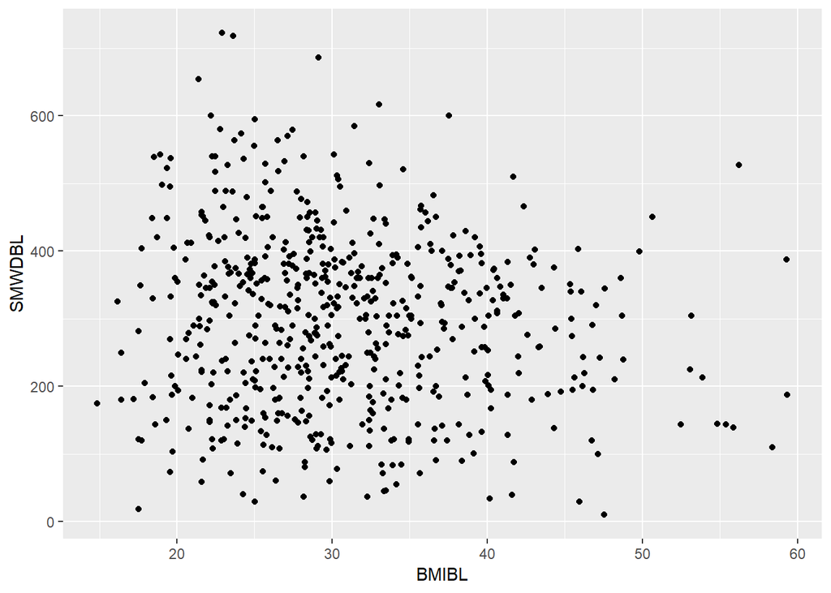

```r
ggplot(data = adsl_ggplot, aes(x = BMIBL, y = SMWDBL)) +
  geom_point()
```

- Use geom_point() to adsl_ggplot with SMWDBL as y and BMIBL as x and SEX as color

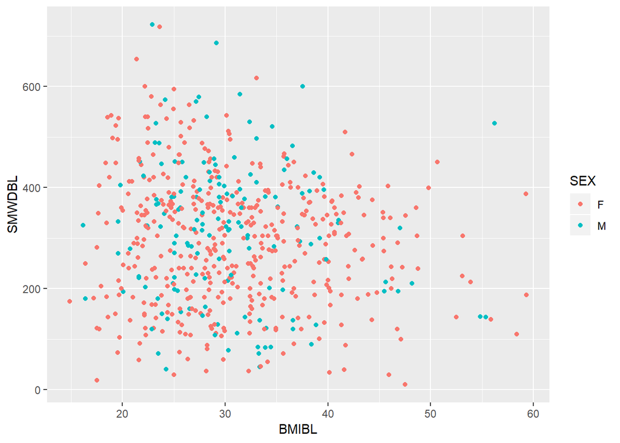

```r
ggplot(data = adsl_ggplot, aes(x = BMIBL, y = SMWDBL, col = SEX)) +
  geom_point()
```

- Add geom_smooth to the previous code Geom_smooth adds a regression line to the plot, and unless otherwise specified, you get the model y~x using loess (locally estimated scatterplot smoothing).

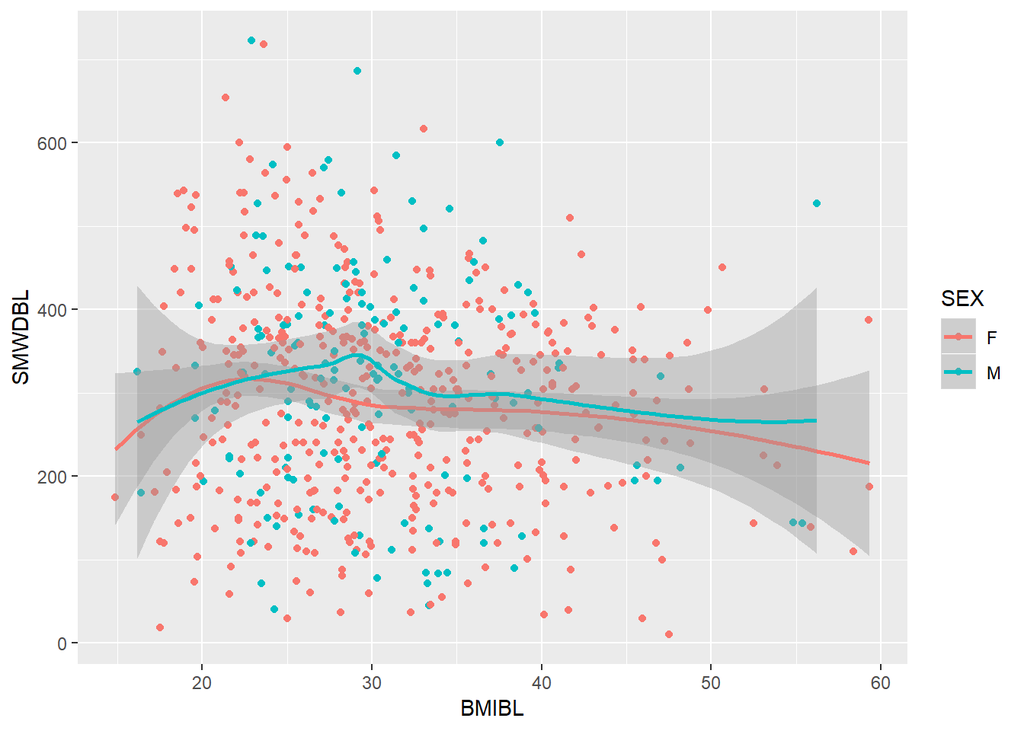

```r
ggplot(data = adsl_ggplot, aes(x = BMIBL, y = SMWDBL, col = SEX)) +
  geom_point() +
  geom_smooth()
```

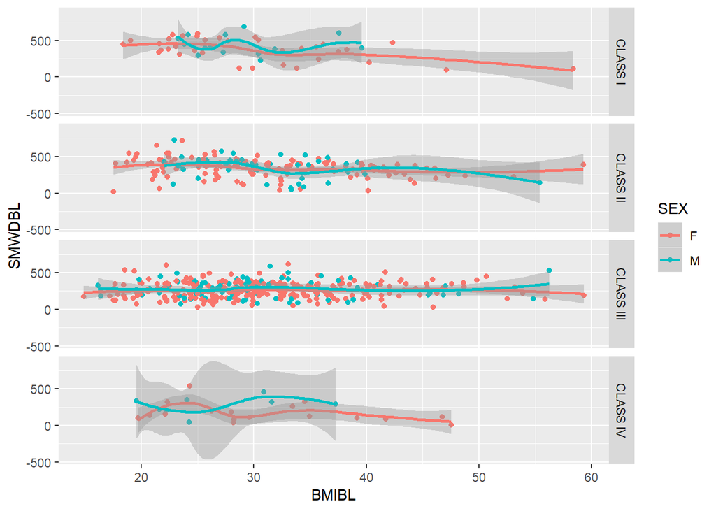

```r
ggplot(data = adsl_ggplot, aes(x = BMIBL, y = SMWDBL, col = SEX)) +
  geom_point() +
  geom_smooth() +
  facet_grid(WHOFCBL ~.)
```

2. Part 2 - Aesthetics
- We will keep adsl_ggplot as a dataset
- Use geom_point() where alpha = 0.5 to adsl_ggplot with SMWDBL as y and BMIBL as x, AGE as color. Here the alpha parameter controls transparency. Why not try a few values?

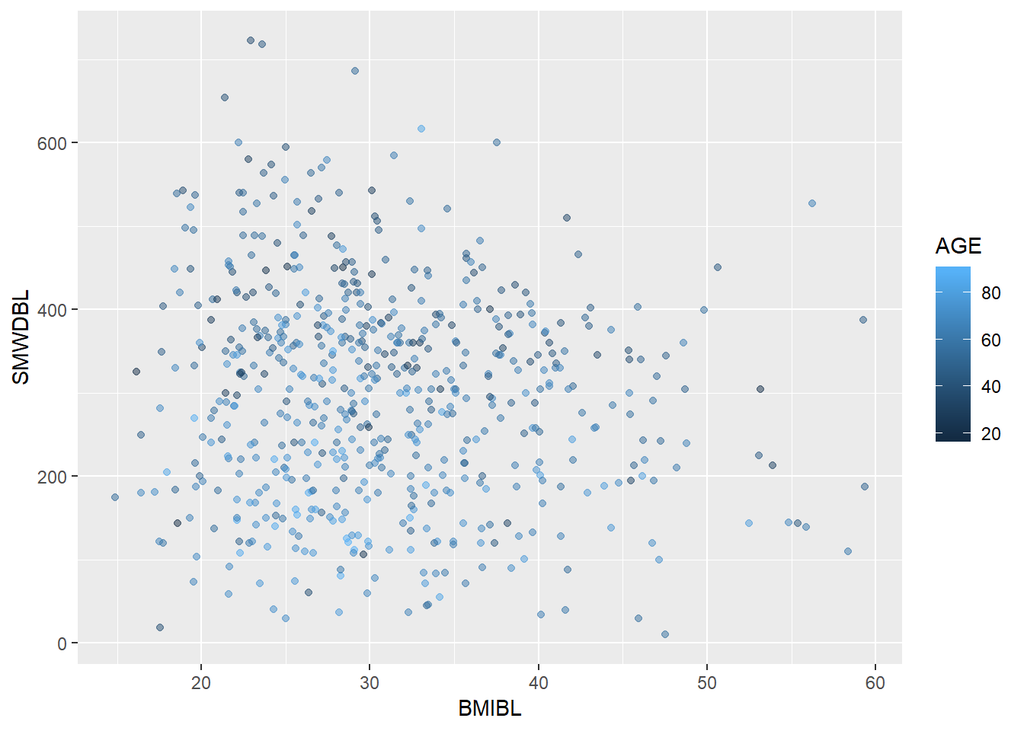

```r
ggplot(data = adsl_ggplot, aes(x = BMIBL, y = SMWDBL, col = AGE)) +
  geom_point(alpha = 0.5)
```

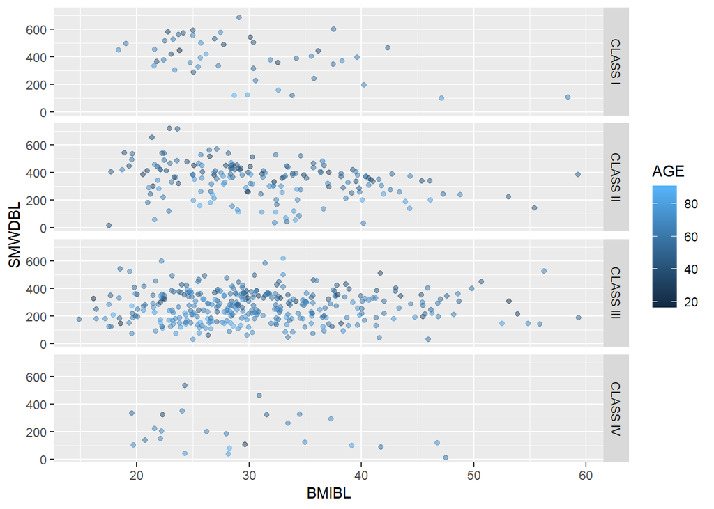

```r
ggplot(data = adsl_ggplot, aes(x = BMIBL, y = SMWDBL, col = AGE)) +
  geom_point(alpha=0.5) +
  facet_grid(WHOFCBL ~.)
```

- Add SEX as shape in the ggplot aesthetic

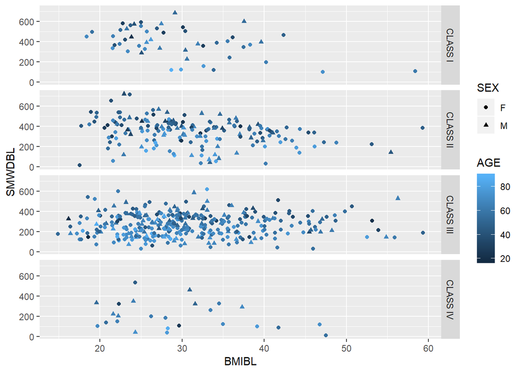

```r
ggplot(data = adsl_ggplot, aes(x = BMIBL, y = SMWDBL, col = AGE, shape = SEX)) +
  geom_point() +
  facet_grid(WHOFCBL ~.)
```

- Add SEX as fill aesthetic and geom_smooth where method = “lm”. Now we are using a linear regression instead of loess

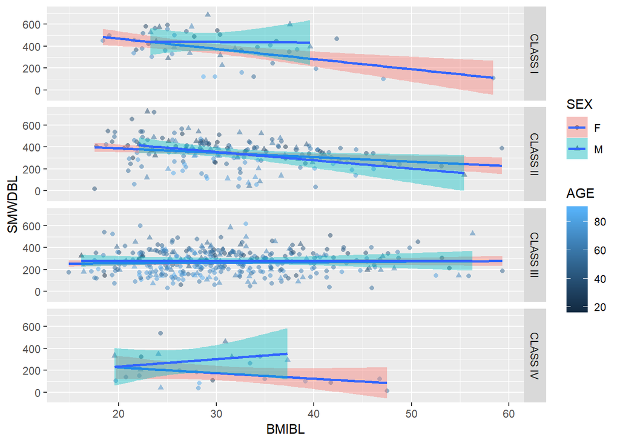

```r
ggplot(data = adsl_ggplot, aes(x = BMIBL, y = SMWDBL, fill = SEX, col = AGE, shape = SEX)) +
  geom_point(alpha = 0.5) +
  facet_grid(WHOFCBL ~.) +
  geom_smooth(method = "lm")
```

- All SUBJID as label in in the ggplot aesthetic and add geom_text whith size = 3

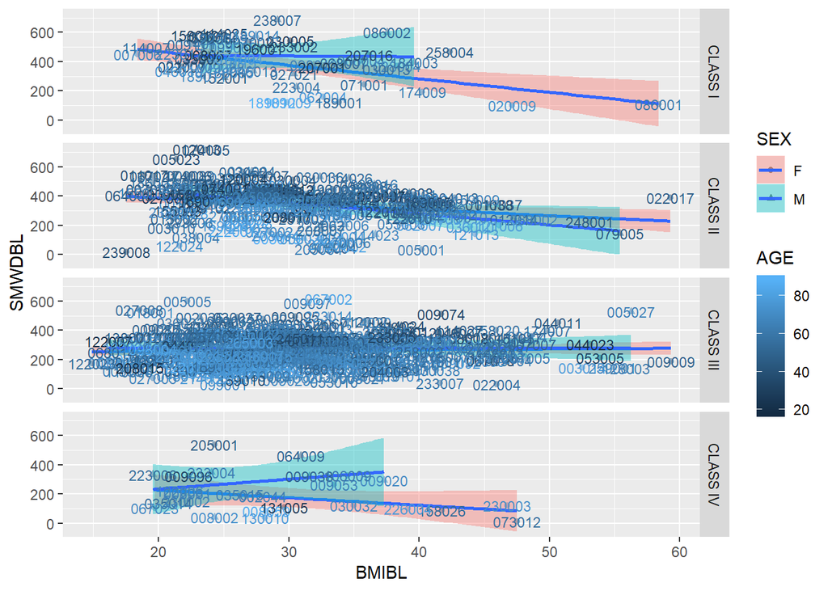

```r
ggplot(data = adsl_ggplot, aes(x = BMIBL, y = SMWDBL, fill = SEX, col = AGE, shape = SEX, label= SUBJID)) +
  geom_point(alpha = 0.5) +
  facet_grid(WHOFCBL ~.) +
  geom_smooth(method = "lm") +
  geom_text(size = 3)
```

3. Part 3 - Geom
- We will keep adsl_ggplot as a dataset
- Now, use WHOFCBL as x and y = SMWDBL and geom_point

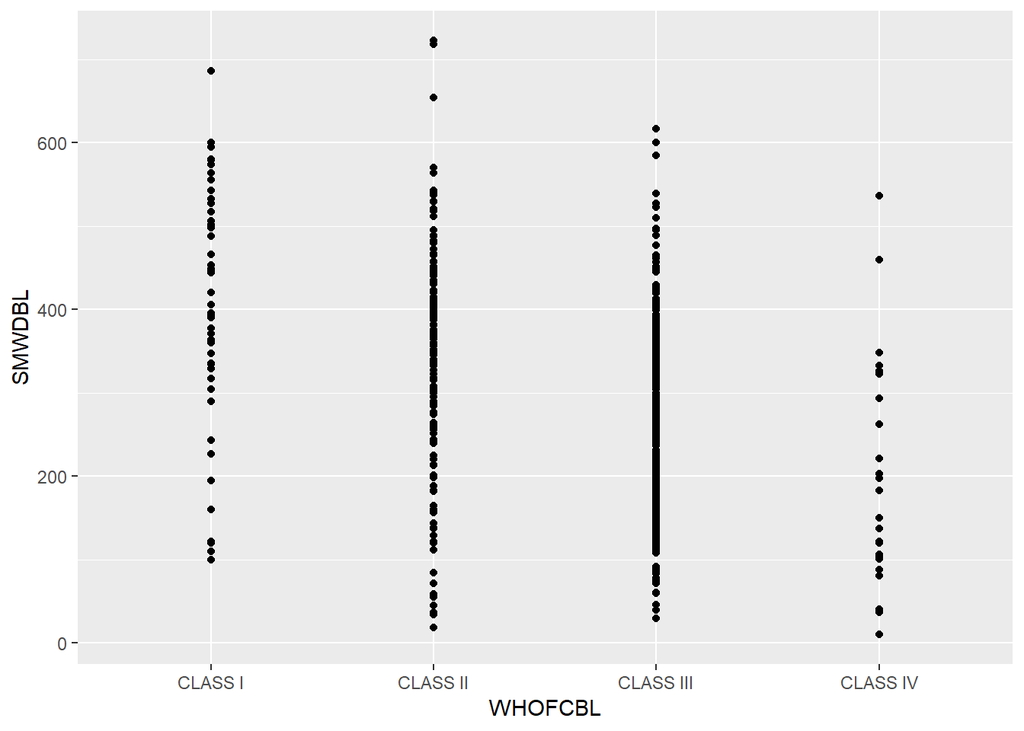

```r
ggplot(data = adsl_ggplot, aes(x = WHOFCBL, y = SMWDBL)) +
  geom_point()
```

- replace geom_point() by geom_jitter and then set width to 0.2 and alpha to 0.3 and shape to 1

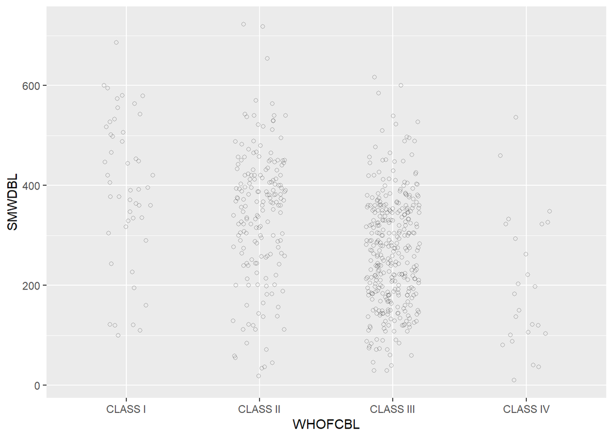

```r
ggplot(data = adsl_ggplot, aes(x = WHOFCBL, y = SMWDBL)) +
  geom_jitter(width = 0.2, alpha = 0.3, shape = 1)
```

- Now drop the y aes and replace WHOFCBL by SMWDBL from ggplot and replace completely by geom_histogram

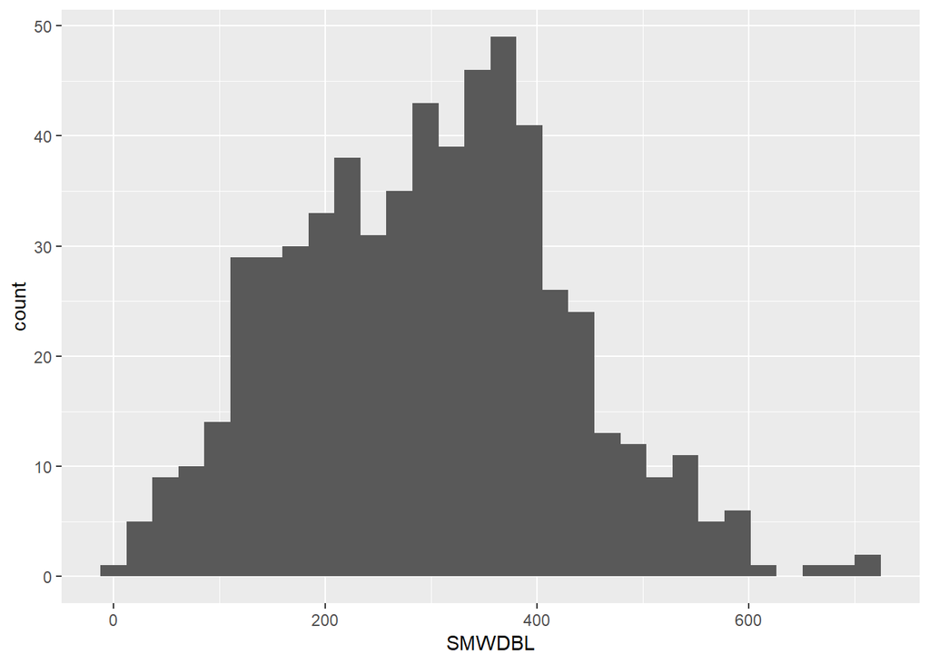

```r
ggplot(data = adsl_ggplot, aes(x = SMWDBL)) +
  geom_histogram()
```

- Create y = ..density.. to the aes from geom_histogram and set fill to WHOFCBL, outside aes set alpha to 0.6

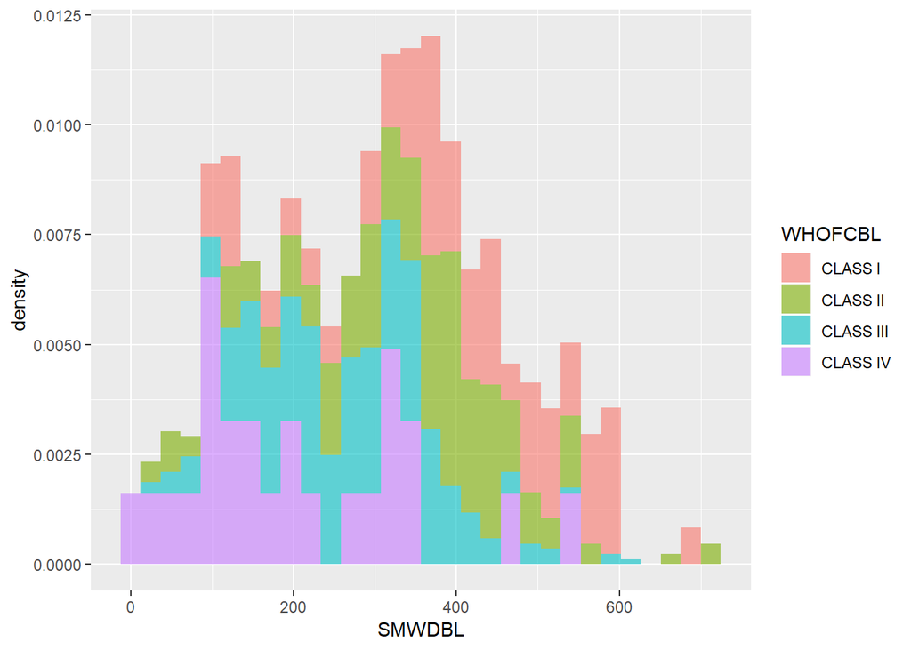

```r
ggplot(data = adsl_ggplot, aes(x = SMWDBL)) +
  geom_histogram(aes(y = ..density.., fill = WHOFCBL), alpha = 0.6)
```

- Define a ne ggplot, map with WHOFCBL as x and fill as SEX and add geom_bar()

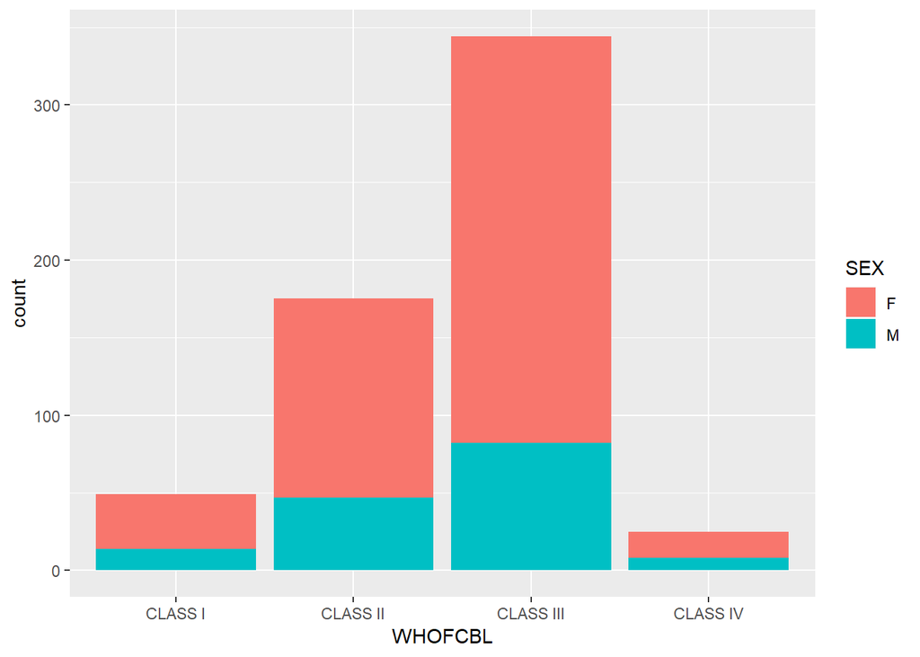

```r
ggplot(data = adsl_ggplot, aes(x = WHOFCBL, fill = SEX)) +
  geom_bar()
```

- Inside geom_bar() add position = “stack” then change to “fill” and then to “dodge”

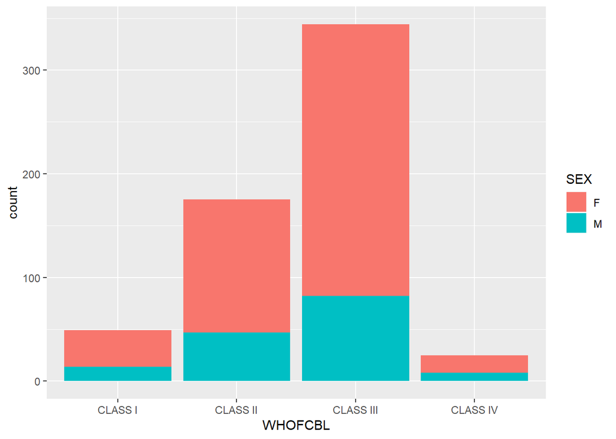

```r
ggplot(data = adsl_ggplot, aes(x = WHOFCBL, fill = SEX)) +
  geom_bar(position = "stack")
```

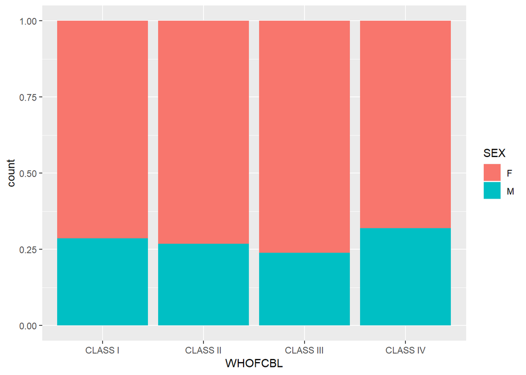

```r
ggplot(data = adsl_ggplot, aes(x = WHOFCBL, fill = SEX)) +
  geom_bar(position = "fill")
```

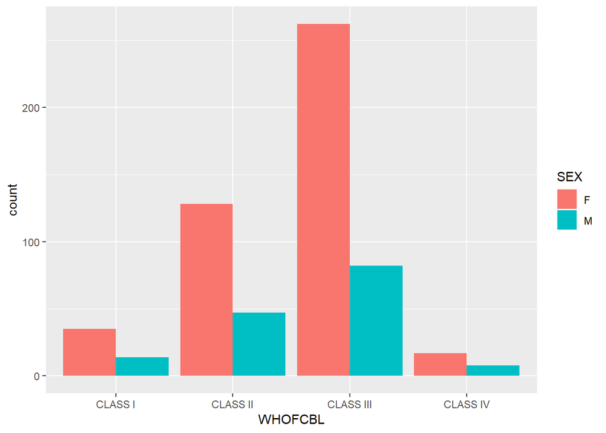

```r
ggplot(data = adsl_ggplot, aes(x = WHOFCBL, fill = SEX)) +
  geom_bar(position = "dodge")
```

# Optional from here on

## Data structures

There are two basic data structures in R: *vectors* and *lists*.

Vectors are of a particular *type*, e.g., *integer*, *double*, or *character*. Vectors can be created using the `c` function, like this:

```r
x <- c(1, 2, 3) # numeric vector
x
```

```
## [1] 1 2 3
```

```r
y <- c("1", "2", "3") # character vector
y
```

```
## [1] "1" "2" "3"
```

Individual elements can be retreived by indexing

```r
y[2] #Returns second element of list
```

```
## [1] "2"
```

Lists are not restricted to a single type and can be used to hold just about anything. They can be created using the `list` function, like this:

```r
z <- list(1, c(1, 2, 3, 4), list(c(1, 2), c("a", "b")))
z
```

```
## [[1]]
## [1] 1
##
## [[2]]
## [1] 1 2 3 4
##
## [[3]]
## [[3]][[1]]
## [1] 1 2
##
## [[3]][[2]]
## [1] "a" "b"
```

Individual elements can be retreived by indexing similar to vectors

```r
z[1]
```

```
## [[1]]
## [1] 1
```

For nested vectors or lists, we can index sublists and subvectors by nesting square brackets

```r
y=c(c(1,2,3))
y[[1]]
```

```
## [1] 1
```

## Creating a sequence

The sequence function creates a sequence from a value to a value. An example, to create an integer vector of integers between 1 to 10

```r
seq(1,10)
```

```
##  [1]  1  2  3  4  5  6  7  8  9 10
```

We can accomplish the same goal as above by using the colon operator.

```r
1:10
```

```
##  [1]  1  2  3  4  5  6  7  8  9 10
```